# Fundamentals of ggplot2

### Exercises

1. Produce a scatter plot with `displ` on the x axis and `hwy` on the y axis, and colour by `drv`. Next, go to [colourbrewer.org](https://colourbrewer2.org/) and find an appropriate colour palette that is colourblind safe. Update your plot with that pallete.

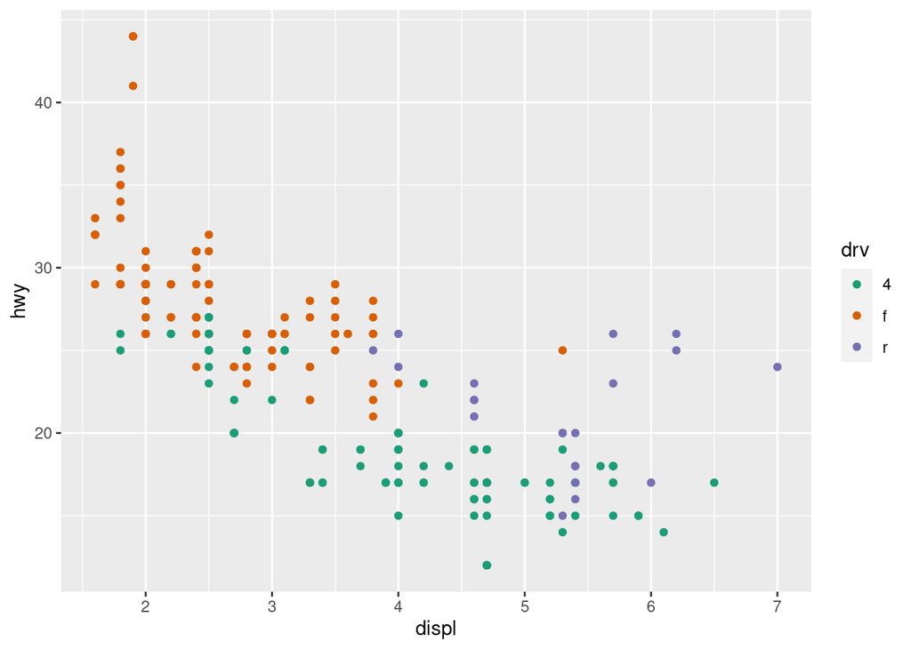

```r
# YOUR CODE HERE
ggplot(mpg, aes(x = displ, y = hwy, colour = drv)) +
  geom_point() +
  scale_colour_brewer(palette = "Dark2")
```

2. Your plot should currently have three breaks on the y axis at 20, 30, and 40. Using `scale_y_continuous()`, try increasing the number of breaks so that there are breaks at 15, 20, 25, 30, 35 and so on. Hint: Check the help file using `?scale_y_continuous`.

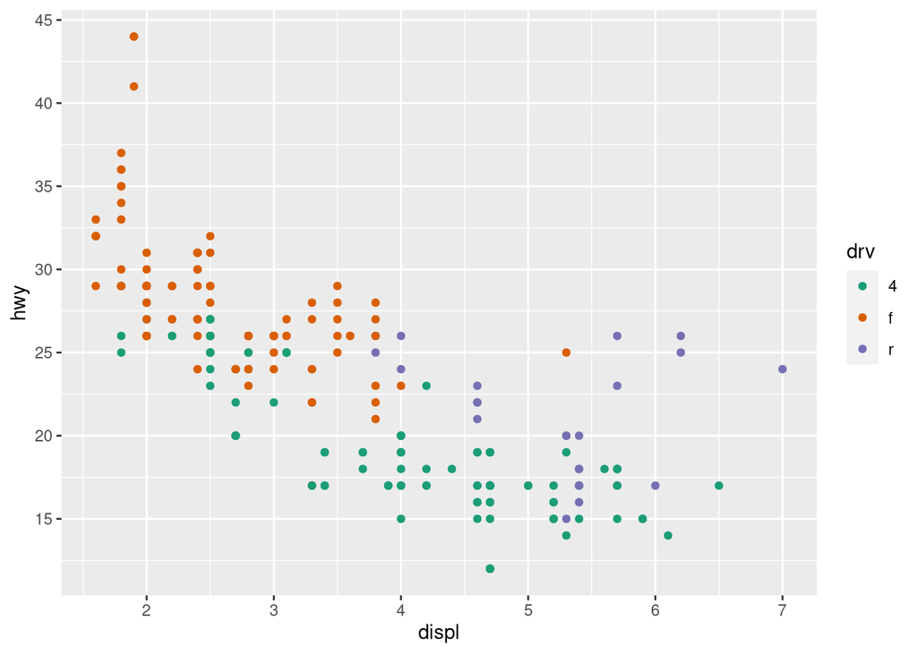

```r
# YOUR CODE HERE
ggplot(mpg, aes(x = displ, y = hwy, colour = drv)) +
  geom_point() +
  scale_colour_brewer(palette = "Dark2") +
  scale_y_continuous(n.breaks = 6)
```

## Facets

Facets are ways of grouping a data plot into multiple different pieces (subplots). This allows you to view a separate plot for each value in a categorical variable. You can construct a plot with multiple facets by using the `facet_wrap()` function. This will produce a “row” of subplots, one for each categorical variable (the number of rows can be specified with an additional argument):

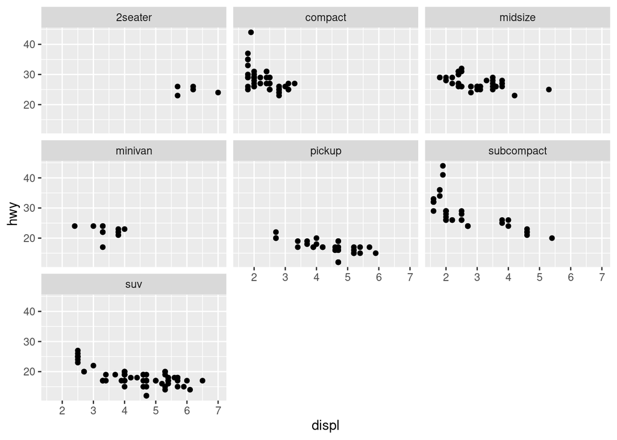

```r
ggplot(mpg, aes(x = displ, y = hwy)) +
  geom_point() +
  facet_wrap(. ~ class)
```

You can also `facet_grid()` to facet your data by more than one categorical variable. Note that we use a tilde (`~`) in our `facet` functions. With `facet_grid()` the variable to the left of the tilde will be represented in the rows and the variable to the right will be represented across the columns.

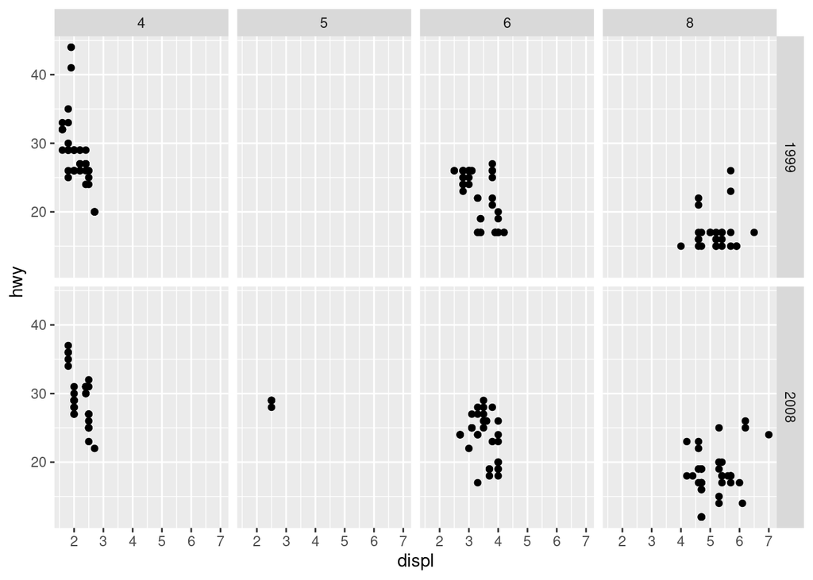

```r
ggplot(mpg, aes(x = displ, y = hwy)) +
  geom_point() +
  facet_grid(year ~ cyl)
```

### Exercises

1. Produce a scatter plot with a smoothed line with `displ` on the x axis and `hwy` on the y axis. Facet the plot by `drv` using `facet_grid()`.

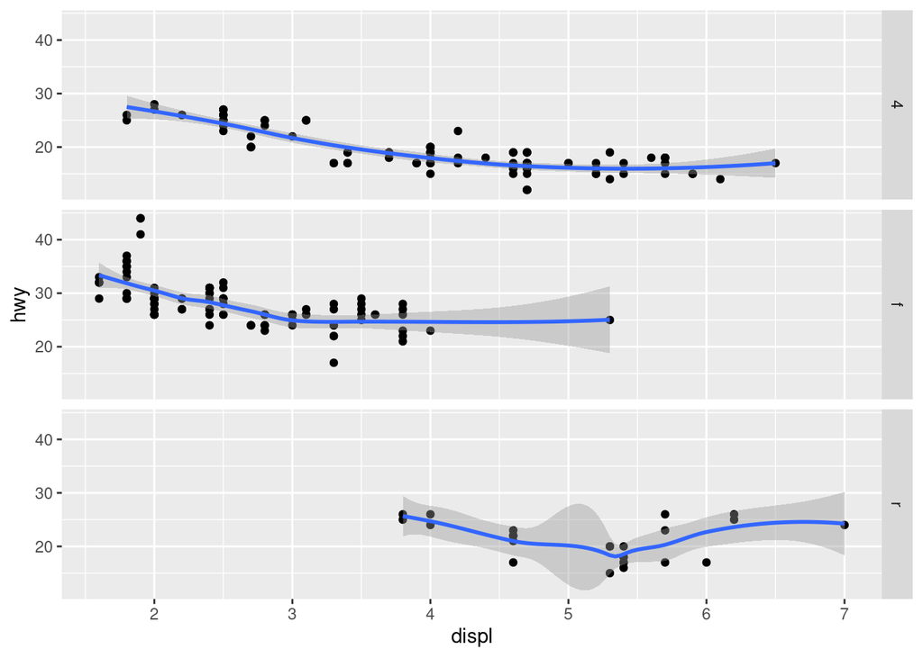

```r
# YOUR CODE HERE
ggplot(mpg, aes(x = displ, y = hwy)) +
    geom_point() +
    geom_smooth() +
    facet_grid(drv ~ .)
```

2. Now try setting `scales='free'` inside `facet_grid()`? What has changed?

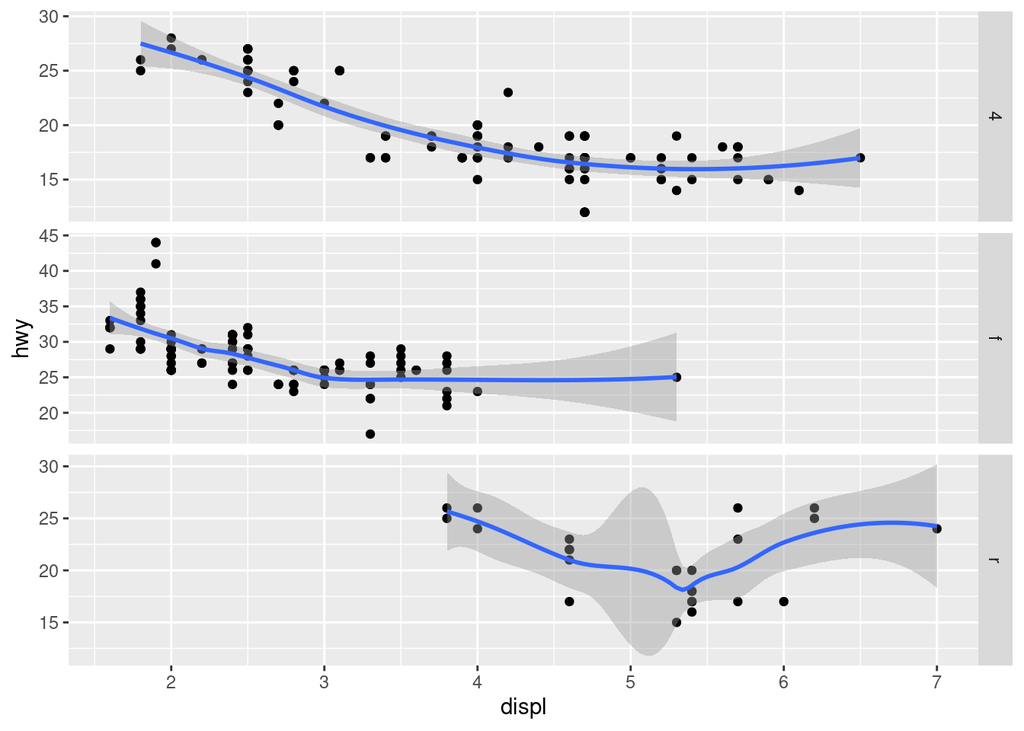

```r
# YOUR CODE HERE
ggplot(mpg, aes(x = displ, y = hwy)) +
    geom_point() +
    geom_smooth() +
    facet_grid(drv ~ ., scales = 'free')
```

## Labels & annotations

Textual labels and annotations (on the plot, axes, geometry, and legend) are an important part of making a plot understandable and communicating information. Although not an explicit part of the Grammar of Graphics (the would be considered a form of geometry), `ggplot` makes it easy to add such annotations.

You can add titles and axis labels to a chart using the `labs()` function (not `labels`, which is a different R function!):

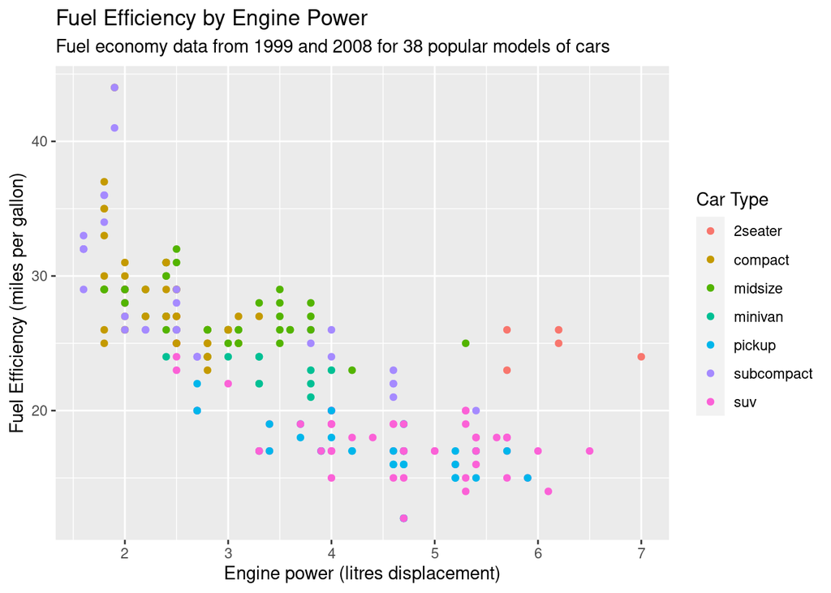

```r
ggplot(mpg, aes(x = displ, y = hwy, colour = class)) +
  geom_point() +
  labs(title = "Fuel Efficiency by Engine Power",
       subtitle = "Fuel economy data from 1999 and 2008 for 38 popular models of cars",
       x = "Engine power (litres displacement)",
       y = "Fuel Efficiency (miles per gallon)",
       colour = "Car Type")
```